# R Notebook

ANALYSIS OF LEC SUBCLUSTERS:DONORS, AVERAGE EXPRESSION AND CORRELATION ################mnbc

##FOR THE WORKING DIRECTORY#####

```r
knitr::opts_chunk$set(echo = TRUE)
# add this:
knitr::opts_knit$set(root.dir = "/mnt/nfs/WORKSP/aminata.sow/LAB_DOCS")

#same result
set.seed(123)
```

#1-load the data

```r
#packages
library(pacman)
p_load(Seurat,SeuratData,Matrix,dplyr,DropletUtils,presto,gprofiler2,ggplot2,patchwork,gplots,cowplot,gprofiler2,openxlsx, plyr,scDblFinder,BiocParallel,RColorBrewer)
```

#2-perform N,S,FVF AND RPCA

```r
####LOAD THE DATA

lec_obj = readRDS("data/process/temp/lec_subset.rds")
table(lec_obj$celltype)
```

```
 LEC
8651
```

#3-CHECK THE TRESHOLD FOR THE PCA AND THE RESOLUTION BEFORE FINDING THE CLUSTERS AFTER INTEGRATION.BASED ON DATA SIZE , WE CAN CHOSE A RANGE OF RESOLUTION

```r
ElbowPlot(lec_obj, ndims = 50)
```

#4-PERFORM INTEGRATION

```r
##perform integration: no need to join layers###
library(harmony)
lec_obj =RunHarmony(
  lec_obj,
  group.by.vars = "orig.ident",
  orig.reduction = "pca",
  dims.use = 1:30
)
Reductions(lec_obj) # to check harmony: run succesfully

#visualization
lec_obj = RunUMAP(lec_obj, reduction = "harmony", dims= 1:30, reduction.name = "umap.harmony")
p1=DimPlot(
  lec_obj,
  reduction = "umap.harmony",
  group.by = c("sample"),
 label.size = 2, shuffle = T
)
p1
```

#4_1 PERFORM DIFFERENT RESOLUTION

```r
library(RColorBrewer)
#for color
# Number of clusters
n_clusters <- length(levels(Idents(lec_obj)))

# Create enough distinct colors
if(n_clusters <= 12){
  my_colors <- brewer.pal(n_clusters, "Paired")
} else {
  # For more than 12 clusters, interpolate a larger palette
  my_colors <- colorRampPalette(brewer.pal(12, "Paired"))(n_clusters)
}

# Set identities if not already
Idents(lec_obj) <- "harmony_clusters"  # replace with your cluster column
#1 Build the nearest-neighbor graph (required before clustering)
lec_obj <- FindNeighbors(lec_obj, dims = 1:30, reduction = "harmony")

##
#2 Create clusters at resolutions from 0.3 to 1.0
for (res in seq(0.3,1, by = 0.1)) {
  lec_obj <- FindClusters(lec_obj, resolution = res)
}

#3 Get all clustering resolution columns from metadata
res_cols <- grep("RNA_snn_res", colnames(lec_obj@meta.data), value = TRUE)


#4 Plot each resolution separately
for (res in res_cols) {
  p <- DimPlot(lec_obj, group.by = res, label = TRUE, reduction =  "umap.harmony") +
       ggtitle(paste("Resolution:", res))
  print(p)
}

#5 (Optional) Combine all plots into one grid for comparison
library(patchwork)

plots <- lapply(res_cols, function(res) {
  DimPlot(lec_obj, group.by = res, label = TRUE, reduction = "umap.harmony") +
    ggtitle(paste("Resolution:", res))
})

wrap_plots(plots)
```

#3-2 NOW CLUSTERS i took 0.5 because the clusters are well separated,clear boundaries. For the rest we noticed clusters that split again into sub pieces

```r
#### clusters after integration
lec_obj = FindNeighbors(lec_obj, reduction="harmony", dims = 1:30)
lec_obj = FindClusters(lec_obj, resolution =0.5, cluster.name = "harmony_clusters")
```

#3-3 COLORS FOR CLUSTERS(optional)

```r
##plots with the clusters with the resolution chosen

library(RColorBrewer)

# Number of clusters
n_clusters <- length(levels(Idents(lec_obj)))

# Create enough distinct colors
if(n_clusters <= 12){
  my_colors <- brewer.pal(n_clusters, "Paired")
} else {
  # For more than 12 clusters, interpolate a larger palette
  my_colors <- colorRampPalette(brewer.pal(12, "Paired"))(n_clusters)
}

# Set identities if not already
Idents(lec_obj) <- "harmony_clusters"  # replace with your cluster column

# Plot
p = DimPlot(
  lec_obj,
  reduction = "umap.harmony",
  label = TRUE,
  label.size = 5,
  repel = TRUE,
  cols = my_colors

)
p
```

#4-FIND ALL MAKERS

```r
##find all markers###########################
#first
all_markers_lec = FindAllMarkers(
  lec_obj,
  only.pos = TRUE,     # only genes upregulated in each cluster
  min.pct = 0.25,      # minimum % of cells expressing the gene
  logfc.threshold = 0.25
)

#filter for significance(IMPORTANT)
all_markers_lec <- all_markers_lec %>%
  filter(p_val_adj < 0.05, avg_log2FC > 0.25)

##save it for next(important)
library(openxlsx)
write.xlsx(
  all_markers_lec,
  file = "output/temp/all_markers_lec.xlsx"
)
View(all_markers_lec)

###########################for just 30 markers  for the annotation ###############

#1️⃣ Add gene and cluster info
#all_markers_lec$feature <- all_markers_lec$gene
#all_markers_lec$group <- all_markers_lec$cluster

# 2️⃣ Keep only significant markers
#all_markers_lec <- all_markers_lec %>%
  #filter(p_val_adj < 0.05, abs(avg_log2FC) > 0.25)

# 3️⃣ Get cluster IDs
#clusters <- unique(all_markers_lec$group)

# 4️⃣ Extract top 30 genes for each cluster
#top_genes_list <- list()

#for (clust in clusters) {
  #top_genes <- all_markers_lec %>%
    #filter(group == clust) %>%
    #arrange(desc(avg_log2FC)) %>%
    #slice_head(n = 30) %>%
    #pull(feature)

  #top_genes_list[[paste0("cluster_", clust)]] <- top_genes
#}

# 5️⃣ Print top 30 marker genes for each cluster
#for (clust in names(top_genes_list)) {
  #cat("=== ", clust, " ===\n")
  #print(top_genes_list[[clust]])
  #cat("\n")
#}
################
```

# LEST CHECK WHICH CLUSTERS ARE LEC BASEDE ON CANONICAL MARKER LEC FROM THE PAPER

```r
lec_markers <- c("ACKR4","SERPINE1","BMP2","CXCL5","MARCO","MFAP4","PTX3","CLDN11","GJA4")
DotPlot(lec_obj, features = lec_markers, cols = c("lightgrey", "darkgreen"), cluster.idents = T,
        group.by = "harmony_clusters") +
  RotatedAxis() + ggtitle("Expression of Known LEC Markers Across Clusters")
```

#4-1 LET’S REMOVE THE CLUSTER THAT ARE NOT LEC

```r
#remove non-lec-clusters cause lack of markers from lecs
lec_clusters_to_delete = setdiff(levels(Idents(lec_obj)), c("4","12"))
lec_obj = subset(lec_obj, idents = lec_clusters_to_delete)
table(Idents(lec_obj))
```

#5 LETS REPEAT THE SAME PROCESS WITH ONLY THE CLUSTER

```r
#####normalize,runpca,scal....
lec_obj = NormalizeData(lec_obj)
lec_obj = FindVariableFeatures(lec_obj)
lec_obj = ScaleData(lec_obj, vars.to.regress = c("nCount_RNA", "percent.mt"))
lec_obj = RunPCA(lec_obj)
```

#6-INTEGRATE AGAIN

```r
##perform integration: no need to join layers###
library(harmony)
lec_obj =RunHarmony(
  lec_obj,
  group.by.vars = "orig.ident",
  orig.reduction = "pca",
  dims.use = 1:30
)
Reductions(lec_obj) # to check harmony: run succesfully

#visualization
lec_obj = RunUMAP(lec_obj, reduction = "harmony", dims= 1:30, reduction.name = "umap.harmony")
p1=DimPlot(
  lec_obj,
  reduction = "umap.harmony",
  group.by = c("sample"),
 label.size = 2, shuffle = T
)
p1
```

#7-LOOK FOR THE RESOLUTION

```r
#1 Build the nearest-neighbor graph (required before clustering)
lec_obj <- FindNeighbors(lec_obj, dims = 1:30, reduction = "harmony")

#2 Create clusters at resolutions from 0.3 to 1.0
for (res in seq(0.3,1, by = 0.1)) {
  lec_obj <- FindClusters(lec_obj, resolution = res)
}

#3 Get all clustering resolution columns from metadata
res_cols <- grep("RNA_snn_res", colnames(lec_obj@meta.data), value = TRUE)


#4 Plot each resolution separately
for (res in res_cols) {
  p <- DimPlot(lec_obj, group.by = res, label = TRUE, reduction =  "umap.harmony") +
       ggtitle(paste("Resolution:", res))
  print(p)
}

#5 (Optional) Combine all plots into one grid for comparison
library(patchwork)

plots <- lapply(res_cols, function(res) {
  DimPlot(lec_obj, group.by = res, label = TRUE, reduction = "umap.harmony") +
    ggtitle(paste("Resolution:", res))
})

wrap_plots(plots)
```

#7-1-clusters with the resolution choosed

```r
#### clusters after integration
lec_obj = FindNeighbors(lec_obj, reduction="harmony", dims = 1:30)
lec_obj = FindClusters(lec_obj, resolution =0.5, cluster.name = "harmony_clusters")
```

#7-2UMAP WITH THE CHOSEN RESOLUTION

```r
# UMAP colored by clusters at resolution 0.6
p=DimPlot(lec_obj, group.by = "harmony_clusters", reduction = "umap.harmony", label = TRUE) +
  ggtitle("UMAP_LEC - Resolution 0.5")
p
#save
ggsave(filename = "output/temp/umap_resolution_lec.png", plot = p, width = 10, height = 8)
```

#8 find all markerr again. Use different name to make differences from the firsts markers before the removing

```r
##find all markers###########################
#first
all_markers = FindAllMarkers(
  lec_obj,
  only.pos = TRUE,     # only genes upregulated in each cluster
  min.pct = 0.25,      # minimum % of cells expressing the gene
  logfc.threshold = 0.25
)

#filter for significance(IMPORTANT)
all_markers = all_markers %>%
  filter(p_val_adj < 0.05, avg_log2FC > 0.25)


##save it for next(important)
library(openxlsx)
write.xlsx(
  all_markers,
  file = "output/temp/all_markers_filter_lec.xlsx"
)
View(all_markers)
```

#CONTINUE THE PROCESS NOW

#9-THE NUMBER OF CELLS PER DONORS

```r
#change the colname
lec_obj$Donors = lec_obj$orig.ident

#create the metadata
meta= lec_obj@meta.data[, c("harmony_clusters", "Donors")]
table(meta$Donors)


# Count cells per donor
cell_counts_per_donor <- as.data.frame(table(meta$Donors))
colnames(cell_counts_per_donor) <- c("Donor", "CellCount")
```

#9-1PLOTS THE NUMBER OF CELLS PER DONNORS

```r
####

p <- ggplot(cell_counts_per_donor, aes(x = Donor, y = CellCount)) +
  geom_segment(aes(x = Donor, xend = Donor, y = 0, yend = CellCount), size = 1) +
  geom_point(size = 5, color = "steelblue") +
  theme_minimal() +
  labs(
    title = "Number of Cells per Donor (LEC)",
    x = "Donor",
    y = "Cell Count"
  ) +
  theme(
    axis.text.x = element_text(angle = 45, hjust = 1)
  )
p

#save
#ggsave(filename = "output/temp/Numb_LEC_cell_per_Donor.png", plot = p, height = 8, width = 10)
```

#10-THE PROPORTION OF DONORS IN EACH CLUSTERS

```r
  library(dplyr)
library(ggplot2)
library(scales)


# Make sure dplyr functions are used explicitly
meta = lec_obj@meta.data

#the  percentage
donors_counts = meta %>%
  as_tibble() %>%
  dplyr::group_by(harmony_clusters,Donors) %>% #count cells each donor use in each cluster
  dplyr::summarise( n= dplyr::n(),.groups = "drop") %>% #numb of cells
  dplyr::group_by(harmony_clusters) %>%
  dplyr::mutate(proportion = n /sum(n))  #fraction of cells per donor
```

#10-1-PLOT

```r
#####
p <- ggplot(donors_counts, aes(
  x = harmony_clusters,
  y = proportion,
  group = Donors,
  color = Donors
)) +
  geom_line(linewidth = 0.9, alpha = 0.9) +
  geom_point(size = 2.8, alpha = 0.9) +
  scale_y_continuous(labels = scales::percent) +
  # Use a colorblind-friendly palette with distinct colors
  scale_color_brewer(palette = "Set1", name = "Donor") +
  theme_minimal(base_size = 13) +
  labs(
    title = "Donor Proportion Across LEC Clusters",
    x = "Cluster",
    y = "Proportion (%)"
  ) +
  theme(
    panel.grid.minor = element_blank(),
    panel.grid.major.x = element_blank(),
    axis.text.x = element_text(angle = 45, hjust = 1),
    legend.position = "right"
  )
p
#save the plot
ggsave(filename = "output/temp/Proportion_donor_per_LEC_cluster.png", plot = p, height = 8, width = 10)
```

#11 the AverageExpression with markers genes(within clusters)

```r
#1-EXTRACT THE MARKER GENES#####
library(openxlsx)
colnames(all_markers)

#select col#if we have to save it but not necessary
marker = all_markers[, c("gene", "cluster", "avg_log2FC", "p_val_adj")]
#remove duplicate
marker_genes = unique(marker)

#2-GET UNIQUE MARKER GENES
marker_genes = unique(all_markers$gene)

#3 filter MG
#all genes in rna assay
gene_in_lec = rownames(lec_obj[["RNA"]])

#only genes present in the object
marker_genes_filtered = marker_genes[marker_genes %in% gene_in_lec]

length(marker_genes_filtered)  # should be > 0

#4 averageEpression per cluster
avr_exp = AverageExpression(
  lec_obj,
  features = marker_genes_filtered,
  assays = "RNA",
  slot = "data"
)

#3 to get the matrix
avr_exp_matrix = avr_exp$RNA
dim(avr_exp_matrix)

#save (important for later)
saveRDS(avr_exp_matrix, file = "output/temp/avrEx_matrix_lec.RDS")
#load
#avr_exp_matrix = readRDS("output/temp/avrEx_matrix_lec.RDS")
```

#11-1 PLOT

```r
#plot
library(pheatmap)
p=pheatmap(
  avr_exp_matrix,
  scale = "row",
  show_rownames = FALSE,
  clustering_method = "ward.D2",
  main = "Average Expression of Marker Genes per Cluster(LEC)"
)
p
ggsave(
  filename = "output/temp/avr_lec.png",
  plot = p,
  width = 10,
  height = 8
)
```

```r
#1-correlation between clusters(BEST ONE)
#need numeric matrix
avr_exp_matrix = as.matrix(avr_exp$RNA)
cluster_cor = cor(avr_exp_matrix,method = "spearman") # or spearman
```

#12-1-PLOT

```r
#plots
p=pheatmap(
  cluster_cor,
  cluster_rows = TRUE,
  cluster_cols = TRUE,
  display_numbers = TRUE,
  main = "Cluster Correlation based on Markers Genes"
)
ggsave(
  filename =  "output/temp/cor_lec.png",
  plot = p,
  width = 10,
  height = 8
)
```

#13- ANNOTATION

#13-1 DOTPLOT WITH THE MARKER LEC TO MAKE THE ANNOTATION

```r
#cluster.idents = put the similar cluster together

lec_markers <- c("ACKR4","SERPINE1","BMP2","CXCL5","MARCO","MFAP4","PTX3","CLDN11","GJA4")
p=DotPlot(lec_obj, features = lec_markers, cols = c("lightgrey", "darkgreen"), cluster.idents = T,
        group.by = "harmony_clusters") +
  RotatedAxis() + ggtitle("Expression of Known LEC Markers Across Clusters")
p

#save
#ggsave(filename = "output/temp/lec_marker_dot_plot.png", plot = p, width = 10, height = 8)
```

#13-2-ANNOTATIONS BASED ON THE CORRELATION

```r
new_ann = c(
  "0"="bridge","1"="collect","2"="floor","3"="bridge","4"="bridge","5"="medullary-sinus","6"="bridge","7"="bridge","8"="bridge","9"="floor","10"="floor","11"="bridge","12"="floor","13"="bridge"
)

#Save the cell type labels in metadata
lec_obj$new_ann = (mapvalues(
  x = as.character(lec_obj$harmony_clusters),#map numb as string
  from = names(new_ann),
  to = new_ann
))

 #Convert to factor and drop unused levels
lec_obj$new_ann <- factor(lec_obj$new_ann, levels = unique(new_ann))
table(lec_obj$new_ann)
```

#13-3 PLOT

```r
##
plt = DimPlot(
  lec_obj,
  reduction = "umap.harmony",
  group.by = "new_ann",
  label = TRUE,
  repel = TRUE,
  pt.size = 1.5
) +
  labs(color = "LEC Major Type", title = "Cell Types in Lymph Endothelial Cells") +
  theme_classic() +
  theme(
    legend.key.size = unit(1.8, "lines"),   # increase the size of the colored boxes
    legend.text = element_text(size = 20)   # increase the text labels
  )
plt

#save
ggsave(filename = "output/temp/LECCellType.png", plot = plt, width = 12, height = 8)
```

#13-4-PLOT WITH THE MARKERS

```r
####
lec_markers <- c("ACKR4","SERPINE1","BMP2","CXCL5","MARCO","MFAP4","PTX3","CLDN11","GJA4")

p <- DotPlot(
  lec_obj,
  features = lec_markers,
  cols = c("lightgrey", "darkgreen"),
  group.by = "new_ann",
  cluster.idents = TRUE
) +
  RotatedAxis() +
  ggtitle("Expression LEC Markers Across Clusters") +
  theme(
    axis.text.y = element_text(size = 20),  # increase y-axis text
    axis.text.x = element_text(size = 12)   # optional: increase x-axis text
  )
p

#save
ggsave(filename = "output/temp/LECMarker.png", plot = p, width = 12, height = 8)
```

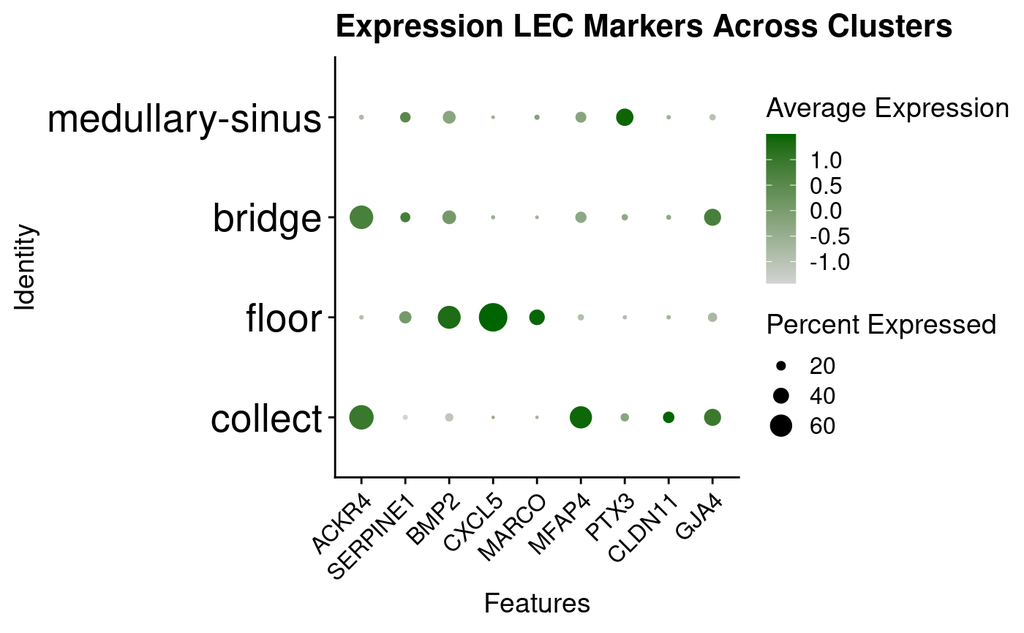

```r
####
lec_markers <- c("ACKR4","SERPINE1","BMP2","CXCL5","MARCO","MFAP4","PTX3","CLDN11","GJA4")

p <- DotPlot(
  lec_obj,
  features = lec_markers,
  cols = c("lightgrey", "darkgreen"),
  group.by = "new_ann",
  cluster.idents = TRUE
) +
  RotatedAxis() +
  ggtitle("Expression LEC Markers Across Clusters") +
  theme(
    axis.text.y = element_text(size = 20),  # increase y-axis text
    axis.text.x = element_text(size = 12)   # optional: increase x-axis text
  )
p

#save
ggsave(filename = "output/temp/LECMarker.png", plot = p, width = 12, height = 8)
```

```r
#save the file
#saveRDS(lec_obj, file = "data/process/temp/lec_obj.RDS")

#run later
lec_obj = readRDS("data/process/temp/lec_obj.RDS")
```